# Walmart Stores Assignment

## Introduction

This document contains my code, graphs, and conclusion regarding the Walmart stores assignment necessary to obtain a grade on R programming for Data Sciences on the Simplilearn Purdue University Data Science Post Graduate Program. .

Each section presents the code, visualization and comments regarding what was asked.

The first section I present the initial codes for the first data wrangling and the setup that generate the data for the answers.

**Thank you for your availability for reading my material!**

Comments and suggestions are more than welcome!

## Code for Data Wrangling

The code below I wrote to do the major data wrangling for this assignment.

Further manipulation would be presented when necessary. For now, the initial questions can be dealt with the code I present below.

```r
#### USED PACKAGES, FOR DATA ANALYSIS, GRAPHS AND COLORS
library(data.table)
library(readr)
library(dlm)
library(collapse)
library(ggplot2)
library(RColorBrewer)
library(dplyr)
library(plotly)
library(FactoMineR)
library(factoextra)
library(cluster)
library(fpc)
library(blogdown)
library(rmdformats)


### READING THE DATA FOR THE ASSIGNMENT IS ON MY LOCAL STORAGE

db <- read_csv('Walmart_Store_sales.csv', locale = locale(encoding = "Latin1"))


#### SETTING THE DATES BECAUSE IT IS IMPORTANT FOR FURTHER DATA MANIPULATION
#### AND CREATING SPECIFIC  MONTHS AND QUARTER FOR EACH OBSERVATION


db$Date <- as.Date(db$Date, "%d-%m-%Y")

db$year = year(db$Date)

db$month = month(db$Date)

db$quarter = quarter(db$Date)


### CALCULATING THE WEEKLY SALES GROWTH RATE, IT WILL BE USED
### ESPECIALLY FOR THE MODELING PHASE

add_vars(db) = G(db, by= ~Store, t = ~Date)

#### REMOVING VARIABLES THAT WILL NOT BE NECESSARY

db['G1.quarter'] <- NULL
db['G1.month'] = db['G1.year'] = db['G1.Unemployement'] = db['G1.Holiday_Flag'] =
  db['G1.Store'] = db[,13] <- NULL
db[,12] <- NULL

#### CREATING THE NATURAL LOGARITHM FOR EACH VARIABLE THAT IS SUITED TO BE
### TRANSFORMED

db$ln_sales = log(db$Weekly_Sales)
db$ln_gas = log(db$Fuel_Price)


#### ADDING THE HOLLIDAYS ON THE DATABASE
#### I ADDED THE AMERICAN INDEPENDENCE DAY DUE TO ITS IMPACT
#### AS IT IS A MID SUMMER HOLLIDAY, PROBABLY DOES IMPACT SALES



db$super_bowl <- ifelse(db$Date == '2010-02-12', 1 , ifelse(
  db$Date == "2011-02-11", 1,0))

db$labor_day =  ifelse(db$Date == '2010-09-10', 1 , ifelse(
  db$Date == "2011-09-09", 1, ifelse( db$Date == '2013-09-06',1,0)))


db$independence =  ifelse(db$Date == '2010-04-09', 1 , ifelse(
  db$Date == "2011-04-08", 1, ifelse( db$Date == '2012-04-06',1,0)))

db$thanks_giving = ifelse(db$Date == '2010-11-26', 1 , ifelse(
  db$Date == "2011-11-25", 1,0))


db$christmas = ifelse(db$Date == '2010-12-31', 1 , ifelse(
  db$Date == "2011-11-30", 1,0))


####### THIS IS A FOR LOOP THAT I WROTE TO ESTIMATE THE COEFFICIENT FOR
####### EACH HOLLIDAY ON EACH ONE OF THE 45 STORES
###### AS I DONT HAVE THE DATA ON STORE'S AGE OR SIZE OR EVEN THE SUROUNDINGS
###### IT IS NICE TO SUPPOSE THAT EACH STORE MIGHT SUFFER DIFFERENT IMPACTS FOR
###### EACH HOLLIDAY.

#### THE CODE BELOW IS TO CREATE THE SPACES THAT THE LOOP RESULTS WILL BE
#### STORED

coefficient_ln_gas$coefficient <- coefficient_labor_day$coefficient <-
  coefficient_independence$coefficient <- coefficient_thanks_giving$coefficient <-
  coefficient_christmas$coefficient <- coefficient_ln_gas$p_value <-
  coefficient_labor_day$p_value <-
  coefficient_independence$p_value <- coefficient_thanks_giving$p_value <-
  coefficient_christmas$p_value <- 0


### THE CODE BELOW IS THE FOR LOOP ITSELF.
### IT RUN A LINEAR REGRESSION FOR EACH STORE
### KEEPS THE COEFFICIENT FOR EACH DUMMY VARIABLE
### RELATED WITH EACH HOLLIDAY AND ITS P-VALUE
setDT(db)

for( i in db$Store)


{
  reg <- lm(ln_sales ~ln_gas + labor_day + independence + thanks_giving + christmas,
           data = db[Store ==i])

coefficient_ln_gas$coefficient[i] <- reg$coefficient[2]
coefficient_labor_day$coefficient[i] <-  reg$coefficient[3]

coefficient_independence$coefficient[i] <-  reg$coefficient[4]

coefficient_thanks_giving$coefficient[i] <-  reg$coefficient[5]

coefficient_christmas$coefficient[i] <-  reg$coefficient[6]

#### P Value

coefficient_ln_gas$p_value[i] <- summary(reg)$coefficient[2,4]
coefficient_labor_day$p_value[i] <- summary(reg)$coefficient[3,4]

coefficient_independence$p_value[i] <-  summary(reg)$coefficient[4,4]

coefficient_thanks_giving$p_value[i] <-  summary(reg)$coefficient[5,4]

coefficient_christmas$p_value[i] <-  summary(reg)$coefficient[6,4]


}

### IFELSE LOOP TO IDENTIFY WHICH STORES HAS COEFFICIENTS THAT
### ARE STATISTICALLY SIGNIFICANT

coefficient_ln_gas$check_coef <- ifelse(coefficient_ln_gas$p_value <0.05,1,0)
colnames(coefficient_ln_gas) <- c ("Store", "p_value_gas","coeff_gas","check_gas")


coefficient_labor_day$check_coef <- ifelse(coefficient_labor_day$p_value <0.05,1,0)

colnames(coefficient_labor_day) <- c ("Store", "p_value_labor","coeff_labor","check_labor")


coefficient_independence$check_coef <-  ifelse(coefficient_independence$p_value <0.05,1,0)
colnames(coefficient_independence) <- c ("Store", "p_value_independence","coeff_independence",
                                         "check_independence")

coefficient_thanks_giving$check_coef <-  ifelse(coefficient_thanks_giving$p_value <0.05,1,0)
colnames(coefficient_thanks_giving) <- c ("Store", "p_value_thanks","coeff_thanks",
                                         "check_thanks")


coefficient_christmas$check_coef <-  ifelse(coefficient_christmas$p_value <0.05,1,0)
colnames(coefficient_christmas) <- c ("Store", "p_value_chris","coeff_chris",
                                          "check_chris")


###### summing for each quarter


db_quarter = db[,.(sales = sum(Weekly_Sales, na.rm=T)),
                by=c("year", 'quarter', 'Store')]



add_vars(db_quarter) = G(db_quarter,  by= ~Store, t = ~c(quarter+year))



##### calculating the median and sd for growth  in each year


setDT(db)

mean_by_week = db[,.(sales_growth_average = mean(G1.Weekly_Sales,na.rm=T),
                      sales_growth_median = median(G1.Weekly_Sales, na.rm=T),
                      sales_growth_sd = sd(G1.Weekly_Sales, na.rm=T)),
                   by=c("Store","year")]







mean_by_week_2 = merge(mean_by_month, coeff_analysis, by='Store')



##### SUM OF THE TOTAL SALES and ranking of stores

total_year = db[,.(sales_total = sum(Weekly_Sales, na.rm=T),
                   dp_sales = sd(Weekly_Sales, na.rm=T),
                   mean_sales = mean(Weekly_Sales, na.rm=T),
                   variation_coeff = sd(Weekly_Sales, na.rm=T)/mean(Weekly_Sales, na.rm=T)),
                    by=c('year', 'Store')]



ranks <- total_year[,.(Store,rank_total_sales = rank(-sales_total),
                       rank_variation_coeff = rank(variation_coeff),
                       rank_dp_sales = rank(-dp_sales)),
                    by=c('year')]

total_year = merge(total_year, ranks, by=c('year','Store'))




mean_by_week_3= merge(mean_by_week_2, total_year, by=c("Store",'year'))



mean_by_week_3$top_10_sales = ifelse(mean_by_week_3$rank_total_sales <11, 1,0)

mean_by_week_3$top_10_var_coef = ifelse(mean_by_week_3$variation_coeff <11, 1,0)


rank_sales_growth = mean_by_week_3[,.(Store,rank_sales_growth =rank(-sales_growth_average)), by=year]

mean_by_week_3 = merge(mean_by_week_3, rank_sales_growth, by=c("Store","year"))


mean_by_week_3$rank_sales_growth = rank(-mean_by_week_3$sales_growth_average)
```

Let´s go for the questions!

## First Question

**Which store has maximum sales?**

Although this is a precise question, there are many ways to answer. I decided the best is to focus on yearly sales figures and the average of weekly sales growth.

The graph presented below shows the **Top 5** stores in total yearly sales. Numbers on the top of the bar shows the store number.

**Top 5 Stores on Yearly Sales**

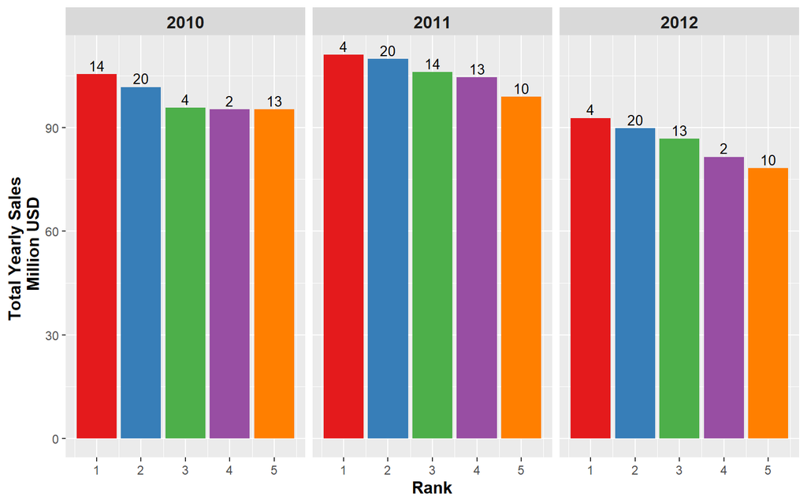

The 2012 figures are the lowest on the the three years, because the samples ends on October 2012.

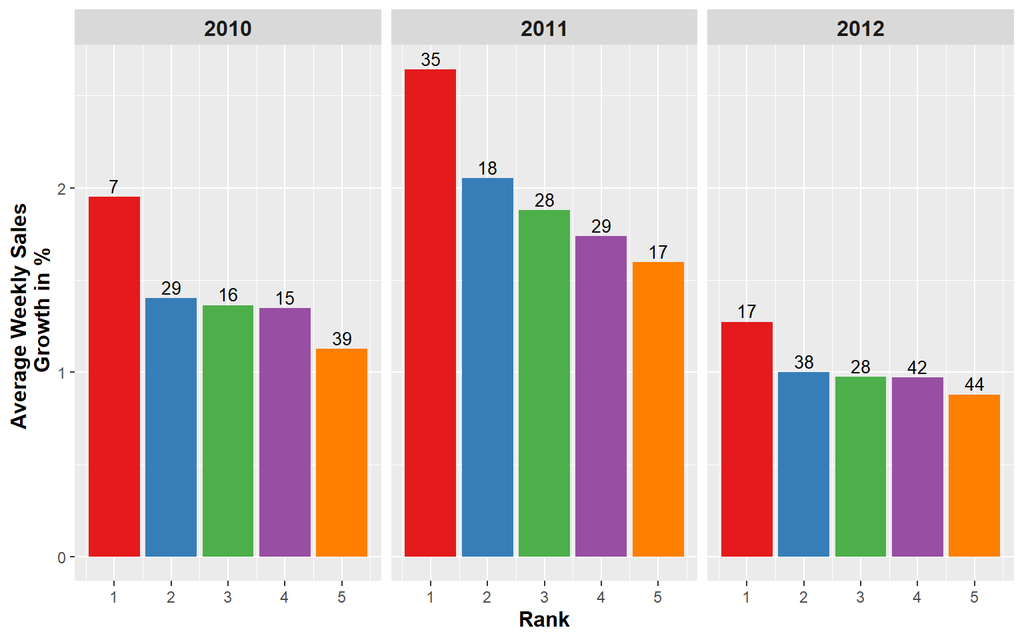

## Second Question

* Which store has maximum standard deviation ? Also, find out the coefficient of variation

The graph below shows the **TOP 5 stores** on high standard deviation (SD) for weekly sales.

**Top 5 Stores on Weekly Sales SD**

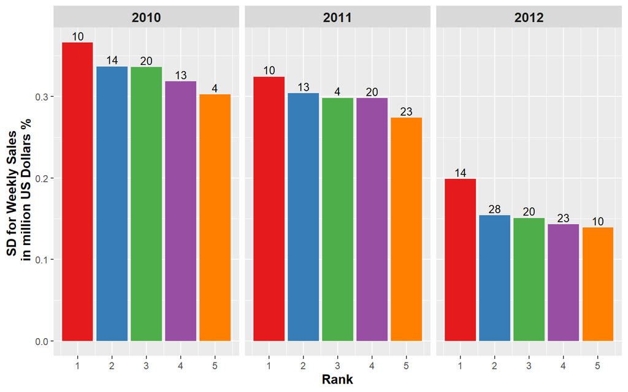

It is easy to note that each metric will give a distinct set of stores. Stores that has a higher sales growth rate tends to be newer stores, while stores that are already consolidated tends to show stable sales figures. As I do not have the data regarding each store age, it is difficult to assess this hypothesis further.

Making a scatter plot with weekly sales and coefficient of variation is very elucidative to deeply understated the stores nature.

**Scatter Plot on average Weekly Sales and Coefficient of Variation for weekly sales**

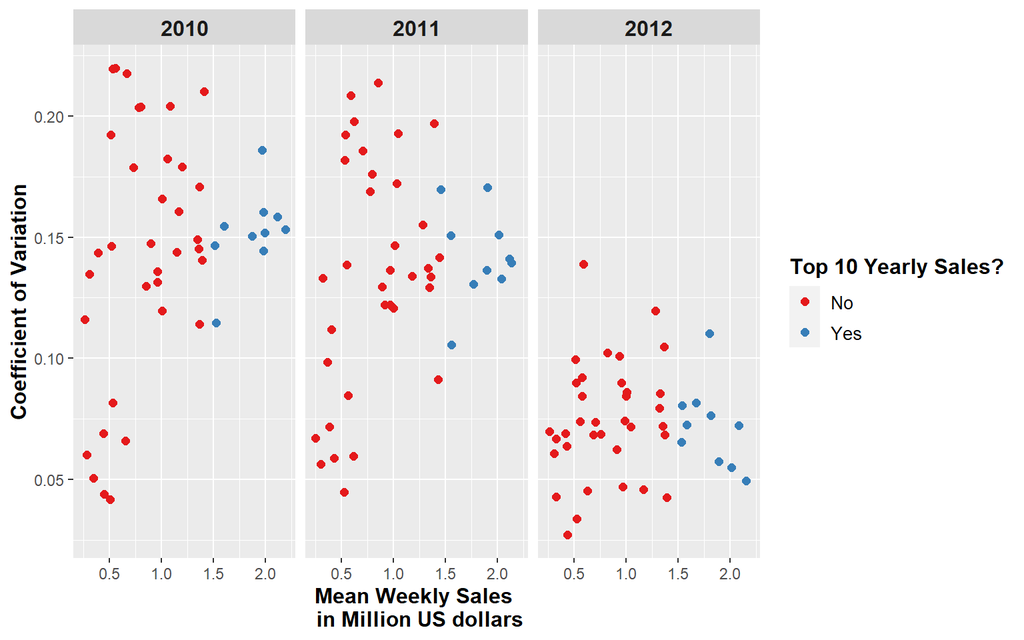

The stores on top 10 sales rank has a mixed behavior regarding its sales variance. On general, higher the sales, SD tends to increase, but this relation is not homogeneous as the scatter plot showed us.

the bottom left stores, (the ones with low coefficient of variation and weekly sales), have an interesting behavior that we will discover when we answer the question regarding holidays.

## Third Question

**Which store/s has good quarterly growth rate in Q32012?**

This question can be answered in many ways, as there is a lot of things to consider when we are trying to define what is *good*. I will define good regarding the median of third quarter growth in comparison with second quarter sales (Quarterly growth rate).

Other aspect that should be pointed out is quarterly sales figures has seasonality pattern, so comparison with other quarters would also be nice, but we only have complete data for 2011, therefore such comparison are difficult. That is why I will focus only on the Third quarter data on each year.

The graph below shows a box plot on quarterly sales growth for Third quarter on each year.

**Box plot on Quarterly sales growth**

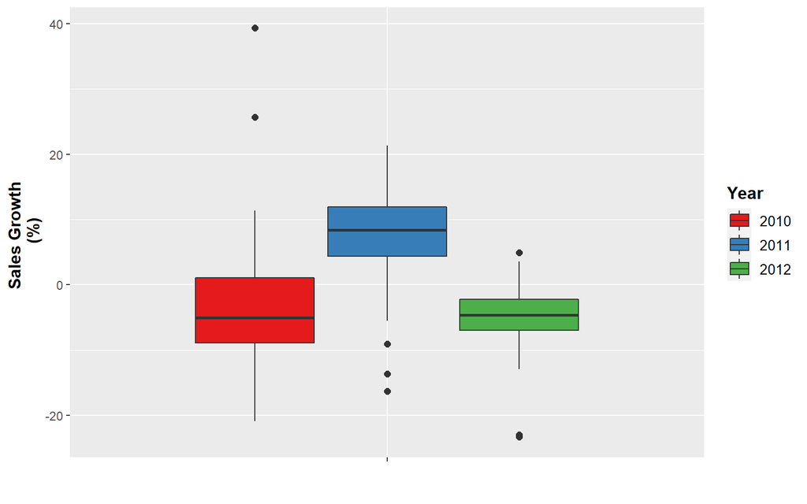